# Проект Предсказания победителя в онлайн-игре

## Задача, решаемая в этом Проекте: предсказание победы по данным о первых 5 минутах игры

## Предметная область: Игра Dota 2

[Dota 2](https://ru.wikipedia.org/wiki/Dota_2) — многопользовательская компьютерная игра жанра MOBA. Игроки играют между собой матчи. В каждом матче участвует две команды, 5 человек в каждой. Одна команда играет за светлую сторону (The Radiant), другая — за тёмную (The Dire). Цель каждой команды — уничтожить главное здание базы противника (трон).

Существуют [разные режимы игры](http://dota2.gamepedia.com/Game_modes/ru), мы будем рассматривать режим [Captain's Mode](http://dota2.gamepedia.com/Game_modes/ru#Captain.27s_Mode), в формате которого происходит большая часть киберспортивных мероприятий по Dota 2.

### Как проходит матч

#### 1. Игроки выбирают героев

Всего в игре чуть более 100 различных героев (персонажей). В начале игры, команды в определенном порядке выбирают героев себе и запрещают выбирать определенных героев противнику (баны). Каждый игрок будет управлять одним героем, в рамках одного матча не может быть несколько одинаковых героев. Герои различаются между собой своими характеристиками и способностями. От комбинации выбранных героев во многом зависит успех команды.

[figure not shown]

#### 2. Основная часть

Игроки могут получать золото и опыт за убийство чужих героев или прочих юнитов. Накопленный опыт влияет на уровень героя, который в свою очередь позволяет улучшать способности. За накопленное золото игроки покупают предметы, которые улучшают характеристики героев или дают им новые способности.

После смерти герой отправляется в "таверну" и возрождается только по прошествии некоторого времени, таким образом команда на некоторое время теряет игрока, однако игрок может досрочно выкупить героя из таверны за определенную сумму золота.

В течение игры команды развивают своих героев, обороняют свою часть поля и нападают на вражескую.

[figure not shown]

#### 3. Конец игры

Игра заканчивается, когда одна из команд разрушет определенное число "башен" противника и уничтожает трон.

[figure not shown]

Итак, решаемая задача:  
По первым 5 минутам игры предсказать, какая из команд победит: Radiant или Dire?

## Набор данных

Набор данных с матчами записан в файле `matches.jsonlines.bz2`. В каталоге `dictionaries` приведены расшифровки идентификаторов, которые присутствуют в записях матчей.

#### Чтение информации о матчах

Информация о матчах записана в сжатом текстовом файле `matches.jsonlines.bz2`, каждая строчка которого содержит объект в формате JSON. Запись в формате JSON преобразуется в python-объект при помощи стандартного модуля `json`. Пример чтения матчей:

```python
import json
import bz2

with bz2.BZ2File('./matches.jsonlines.bz2') as matches_file:
    for line in matches_file:
        match = json.loads(line)

        # Обработка матча
        break
```

#### Описание полей в записи матча

```
{
    "match_id": 247,            # идентификатор матча
    "start_time": 1430514316,   # дата/время начала матча, unixtime
    "lobby_type": 0,            # тип комнаты, в которой собираются игроки
                                #   (расшифровка в dictionaries/lobbies.csv)

    # стадия выбора героев
    "picks_bans": [
        {
            "order": 0,       # порядковый номер действия
            "is_pick": false, # true если команда выбирает героя, false — если банит
            "team": 1,        # команда, совершающая действие (0 — Radiant, 1 — Dire)
            "hero_id": 95     # герой, связанный с действием
                              #    (расшифровка в dictionaries/heroes.csv)
        },
        ...
    ],

    # информация про каждого игрока, список ровно из 10 элементов
    # игроки с индексами от 0 до 4 — из команды Radiant, от 5 до 9 — Dire
    "players": [
        {

            # герой игрока (расшифровка в dictionaries/heroes.csv)
            "hero_id": 67,

            # временные ряды (отсчеты указаны в поле "times")
            "xp_t": [0, 13, 115, 177, 335, ...],   # опыт
            "gold_t": [0, 99, 243, 343, 499, ...], # золото + стоимость всех купленных вещей (net worth)
            "lh_t": [0, 0, 2, 2, 2, ...],          # количество убитых юнитов (не героев) противника

            # список событий: улучшение способностей героя
            "ability_upgrades": [
                {
                    "time": 51,      # игровое время
                    "level": 1,      # уровень игрока, на котором произошло улучшение
                    "ability": 5334  # способность, которая была улучшена
                                     # (расшифровка в dictionaries/abilities.csv)
                },
                ...
            ],

            # список событий: убийства
            "kills_log": [
                {
                    "time": 831,    # игровое время
                    "player": 7,    # индекс игрока, чей герой был убит
                                    #   (не заполнено, если был убит не герой)
                    "unit": "npc_dota_hero_viper" # тип убитого юнита
                },
                ...
            ],

            # список событий: покупка предметов
            "purchase_log": [
                {
                    "time": -73,     # игровое время
                                     #   точка отсчета игрового времени (ноль) начинается через
                                     #   несколько минут после фактического начала матча, поэтому
                                     #   время некоторых событий может быть отрицательным
                    "item_id": 44    # купленный предмер (расшифровка в dictionaries/items.csv)
                },
                ...
            ]

            # список событий: выкуп героя из таверны
            "buyback_log": [
                {"time": 2507},
                ...
            ],

            # список событий: установка героем "наблюдателей", позволяющих команде
            # следить за чатью игрового поля на некотором расстоянии от точки установки
            "obs_log": [
                {
                    "time": 1711,    # игровое время установки
                    "xy": [111, 130] # координаты игрового поля
                },
                ...
            ],
            "sen_log": [], # аналогично полю obs_log, другой тип "наблюдателя"

        },
        ...
    ],

    # отсчеты игрового времени, в которые вычисляются значения временных рядов
    "times": [0, 60, 120, 180, ...],

    # ключевые события игры
    "objectives": [
        {
            "time": 198,           # время события
            "type": "firstblood",  # тип события
            "player1": 6,          # параметры события, могут содержать
            "player2": 1           #   индексы игроков (player),
                                   #   номер команды (team, 0 — Radiant, 1 — Dire)
        },
        {
            "time": 765,
            "type": "tower_kill",
            "player": 7,
            "team": 1
        },
        ...
    ]

    # итог матча (отсутствует в тестовых матчах)
    "finish": {
        "duration": 2980,             # длительность в секундах
        "radiant_win": false,         # true, если победила команда Radiant
        "tower_status_radiant": 0,    # состояние башен у команд к концу игры
        "tower_status_dire": 1972,    #   (см. описание битовой маски)
        "barracks_status_dire": 63,   # состояние бараков у команд к концу игры
        "barracks_status_radiant": 0  #   (см. описание битовой маски)
    }
}
```

#### Описание полей состояния башен и бараков

Состояние башен к концу игры задается целым числом, закодировано в битах:

```
┌─┬─┬─┬─┬─────────────────────── Not used.
│ │ │ │ │ ┌───────────────────── Ancient Bottom
│ │ │ │ │ │ ┌─────────────────── Ancient Top
│ │ │ │ │ │ │ ┌───────────────── Bottom Tier 3
│ │ │ │ │ │ │ │ ┌─────────────── Bottom Tier 2
│ │ │ │ │ │ │ │ │ ┌───────────── Bottom Tier 1
│ │ │ │ │ │ │ │ │ │ ┌─────────── Middle Tier 3
│ │ │ │ │ │ │ │ │ │ │ ┌───────── Middle Tier 2
│ │ │ │ │ │ │ │ │ │ │ │ ┌─────── Middle Tier 1
│ │ │ │ │ │ │ │ │ │ │ │ │ ┌───── Top Tier 3
│ │ │ │ │ │ │ │ │ │ │ │ │ │ ┌─── Top Tier 2
│ │ │ │ │ │ │ │ │ │ │ │ │ │ │ ┌─ Top Tier 1
│ │ │ │ │ │ │ │ │ │ │ │ │ │ │ │
0 0 0 0 0 0 0 0 0 0 0 0 0 0 0 0
```

Состояние бараков к концу игры закодировано в битах целого числа:

```
┌─┬───────────── Not used.
│ │ ┌─────────── Bottom Ranged
│ │ │ ┌───────── Bottom Melee
│ │ │ │ ┌─────── Middle Ranged
│ │ │ │ │ ┌───── Middle Melee
│ │ │ │ │ │ ┌─── Top Ranged
│ │ │ │ │ │ │ ┌─ Top Melee
│ │ │ │ │ │ │ │
0 0 0 0 0 0 0 0
```

## Извлечение признаков

Скрипт extract_features.py производит извлечение признаков из известной информации о матче за первые 5 игровых минут, составляет из них таблицу. Таблица помогает быстрее сформировать матрицу объект-признак, вектор ответов и начать применять методы машинного обучения для решения поставленной задачи.

Признаки, представленные в таблице `features.csv`, по мнению экспертов в предметной области являются наиболее важными для решения задачи предсказания победы команды. Тем не менее, не обязательно использовать эти признаки в исходном виде для применения методов машинного обучения — при желании можно сделать новые признаки из имеющихся. Более того, признаки в файле `features.csv` содержат не всю информацию, известную про матч за первые 5 игровых минут. Можно использовать скрипт `extract_features.py` как пример и добавлять новые признаки для улучшения качества предсказания.

#### Пример чтения файла с признаками

```python
import pandas
features = pandas.read_csv('./features.csv', index_col='match_id')

features.head()
```

| match_id | start_time | lobby_type | r1_hero | r1_level | r1_xp | r1_gold | r1_lh | r1_kills | r1_deaths | r1_items | ... | dire_boots_count | dire_ward_observer_count | dire_ward_sentry_count | dire_first_ward_time | duration | radiant_win | tower_status_radiant | tower_status_dire | barracks_status_radiant | barracks_status_dire |
| --- | --- | --- | --- | --- | --- | --- | --- | --- | --- | --- | --- | --- | --- | --- | --- | --- | --- | --- | --- | --- | --- |
| 0 | 1430198770 | 7 | 11 | 5 | 2098 | 1489 | 20 | 0 | 0 | 7 | ... | 4 | 2 | 2 | -52 | 2874 | 1 | 1796 | 0 | 51 | 0 |
| 1 | 1430220345 | 0 | 42 | 4 | 1188 | 1033 | 9 | 0 | 1 | 12 | ... | 4 | 3 | 1 | -5 | 2463 | 1 | 1974 | 0 | 63 | 1 |
| 2 | 1430227081 | 7 | 33 | 4 | 1319 | 1270 | 22 | 0 | 0 | 12 | ... | 4 | 3 | 1 | 13 | 2130 | 0 | 0 | 1830 | 0 | 63 |
| 3 | 1430263531 | 1 | 29 | 4 | 1779 | 1056 | 14 | 0 | 0 | 5 | ... | 4 | 2 | 0 | 27 | 1459 | 0 | 1920 | 2047 | 50 | 63 |
| 4 | 1430282290 | 7 | 13 | 4 | 1431 | 1090 | 8 | 1 | 0 | 8 | ... | 3 | 3 | 0 | -16 | 2449 | 0 | 4 | 1974 | 3 | 63 |

5 rows × 108 columns

#### Описание признаков в таблице

- `match_id`: идентификатор матча в наборе данных
- `start_time`: время начала матча (unixtime)
- `lobby_type`: тип комнаты, в которой собираются игроки (расшифровка в `dictionaries/lobbies.csv`)
- Наборы признаков для каждого игрока (игроки команды Radiant — префикс `rN`, Dire — `dN`):
  - `r1_hero`: герой игрока (расшифровка в dictionaries/heroes.csv)
  - `r1_level`: максимальный достигнутый уровень героя (за первые 5 игровых минут)
  - `r1_xp`: максимальный полученный опыт
  - `r1_gold`: достигнутая ценность героя
  - `r1_lh`: число убитых юнитов
  - `r1_kills`: число убитых игроков
  - `r1_deaths`: число смертей героя
  - `r1_items`: число купленных предметов
- Признаки события "первая кровь" (first blood). Если событие "первая кровь" не успело произойти за первые 5 минут, то признаки принимают пропущенное значение
  - `first_blood_time`: игровое время первой крови
  - `first_blood_team`: команда, совершившая первую кровь (0 — Radiant, 1 — Dire)
  - `first_blood_player1`: игрок, причастный к событию
  - `first_blood_player2`: второй игрок, причастный к событию
- Признаки для каждой команды (префиксы `radiant_` и `dire_`)
  - `radiant_bottle_time`: время первого приобретения командой предмета "bottle"
  - `radiant_courier_time`: время приобретения предмета "courier"
  - `radiant_flying_courier_time`: время приобретения предмета "flying_courier"
  - `radiant_tpscroll_count`: число предметов "tpscroll" за первые 5 минут
  - `radiant_boots_count`: число предметов "boots"
  - `radiant_ward_observer_count`: число предметов "ward_observer"
  - `radiant_ward_sentry_count`: число предметов "ward_sentry"
  - `radiant_first_ward_time`: время установки командой первого "наблюдателя", т.е. предмета, который позволяет видеть часть игрового поля
- Итог матча (данные поля отсутствуют в тестовой выборке, поскольку содержат информацию, выходящую за пределы первых 5 минут матча)
  - `duration`: длительность
  - `radiant_win`: 1, если победила команда Radiant, 0 — иначе
  - Состояние башен и барраков к концу матча (см. описание полей набора данных)
    - `tower_status_radiant`
    - `tower_status_dire`
    - `barracks_status_radiant`
    - `barracks_status_dire`

## Метрика качества

В качестве метрики качества мы будем использовать площадь под ROC-кривой (AUC-ROC). Обратите внимание, что AUC-ROC — это метрика **качества для алгоритма**, выдающего оценки принадлежности первому классу. Оба алгоритма, которые будут использоваться в проекте — градиентный бустинг, и логистическая регрессия — умеют выдавать такие оценки. Для этого нужно получать предсказания с помощью функции **predict_proba**. Она возвращает **два столбца**: первый содержит оценки принадлежности нулевому классу, второй — первому классу. Нам нужны значения **из второго** столбца:

```
pred = clf.predict_proba(X_test)[:, 1]
```

## Схема решения задачи Проекта

Нужно будет провести описанные ниже два этапа исследования, написать по результатам каждого этапа небольшой отчет (ниже приведен план отчета), и представить для ревью данный отчет и код, с помощью которого выполнено задание.

**Обратим внимание:** высокое качество работы на кросс-валидации (близкое к 100%) — это в первую очередь **повод задуматься** о том, правильно ли была обучена модель. Возможно, были применены некорректные признаки **из будущего** или настройка проводилась на **неправильном наборе** признаков.

### Подход 1: градиентный бустинг "в лоб"

Один из самых универсальных алгоритмов является **градиентный бустинг**. Он **не очень требователен** к данным, восстанавливает **нелинейные** зависимости, и хорошо работает на многих наборах данных, что и обуславливает его популярность. Вполне разумной мыслью будет попробовать именно его **в первую** очередь.

#### План

1. Считаем таблицу с признаками из файла features.csv с помощью кода, приведенного выше. Удалим признаки, связанные с итогами матча (они помечены в описании данных как отсутствующие в тестовой выборке).
2. Проверим выборку на наличие пропусков с помощью функции count(), которая для каждого столбца показывает число заполненных значений. Много ли пропусков в данных? Запишем названия признаков, имеющих пропуски, и попробуем для любых двух из них дать обоснование, почему их значения могут быть пропущены.
3. Заменим пропуски на нули с помощью функции fillna(). На самом деле этот способ является предпочтительным для логистической регрессии, поскольку он позволит пропущенному значению не вносить никакого вклада в предсказание. Для деревьев часто лучшим вариантом оказывается замена пропуска на очень большое или очень маленькое значение — в этом случае при построении разбиения вершины можно будет отправить объекты с пропусками в отдельную ветвь дерева. Также есть и другие подходы — например, замена пропуска на среднее значение признака. При желании можно попробовать разные подходы к обработке пропусков и сравнить их между собой.
4. Какой столбец содержит целевую переменную? Запишем его название.
5. Забудем, что в выборке есть категориальные признаки, и попробуем обучить градиентный бустинг над деревьями на имеющейся матрице "объекты-признаки". Зафиксируем генератор разбиений для кросс-валидации по 5 блокам (KFold), не забудем перемешать при этом выборку (shuffle=True), поскольку данные в таблице отсортированы по времени, и без перемешивания можно столкнуться с нежелательными эффектами при оценивании качества. Оценим качество градиентного бустинга (GradientBoostingClassifier) с помощью данной кросс-валидации, попробуйте при этом разное количество деревьев (как минимум протестируйте следующие значения для количества деревьев: 10, 20, 30). Долго ли настраивались классификаторы? Достигнут ли оптимум на испытанных значениях параметра n_estimators, или же качество, скорее всего, продолжит расти при дальнейшем его увеличении?

##### Что будет в отчете

В отчете по данному этапу будет следующее:

1. Какие признаки имеют пропуски среди своих значений? Что могут означать пропуски в этих признаках (ответим на этот вопрос для двух любых признаков)?
2. Как называется столбец, содержащий целевую переменную?
3. Как долго проводилась кросс-валидация для градиентного бустинга с 30 деревьями? Инструкцию по измерению времени можно найти ниже по тексту. Какое качество при этом получилось? Напомним, что в данном Проекте мы используем метрику качества AUC-ROC.
4. Имеет ли смысл использовать больше 30 деревьев в градиентном бустинге? Что бы можно предложить делать, чтобы ускорить его обучение при увеличении количества деревьев?

##### Возможные лайфхаки

- Если все работает очень медлено:
  - Использовать для обучения и кросс-валидации не всю выборку, а некоторое ее подмножество — например, половину объектов. Подмножество лучше всего брать случайным, а не формировать его из первых m объектов.
  - Попробуем упростить модель — например, уменьшить глубину деревьев в градиентом бустинге (max_depth).

##### Измерение времени работы кода

```
import time
import datetime

start_time = datetime.datetime.now()

time.sleep(3) # вместо этой строчки разместить замеряемый код

print 'Time elapsed:', datetime.datetime.now() - start_time
```

### Подход 2: логистическая регрессия

Линейные методы работают гораздо быстрее композиций деревьев, поэтому кажется разумным воспользоваться именно ими для ускорения анализа данных. Одним из наиболее распространенных методов для классификации является логистическая регрессия.

**Важно:** учтем, что линейные алгоритмы чувствительны к масштабу признаков! Может пригодиться sklearn.preprocessing.StandartScaler.

#### План

1. Оценим качество логистической регрессии (sklearn.linear_model.LogisticRegression с L2-регуляризацией) с помощью кросс-валидации по той же схеме, которая использовалась для градиентного бустинга. Подберем при этом лучший параметр регуляризации (C). Какое наилучшее качество у вас получилось? Как оно соотносится с качеством градиентного бустинга? Чем можно объяснить эту разницу? Быстрее ли работает логистическая регрессия по сравнению с градиентным бустингом?
2. Среди признаков в выборке есть категориальные, которые мы использовали как числовые, что вряд ли является хорошей идеей. Категориальных признаков в этой задаче одиннадцать: lobby_type и r1_hero, r2_hero, ..., r5_hero, d1_hero, d2_hero, ..., d5_hero. Уберем их из выборки, и проведем кросс-валидацию для логистической регрессии на новой выборке с подбором лучшего параметра регуляризации. Изменилось ли качество? Чем можно это объяснить?
3. На предыдущем шаге мы исключили из выборки признаки rM_hero и dM_hero, которые показывают, какие именно герои играли за каждую команду. Это важные признаки — герои имеют разные характеристики, и некоторые из них выигрывают чаще, чем другие. Выясним из данных, сколько различных идентификаторов героев существует в данной игре (может пригодиться фукнция unique или value_counts).
4. Воспользуемся подходом "мешок слов" для кодирования информации о героях. Пусть всего в игре имеет N различных героев. Сформируем N признаков, при этом i-й будет равен нулю, если i-й герой не участвовал в матче; единице, если i-й герой играл за команду Radiant; минус единице, если i-й герой играл за команду Dire. Ниже можно найти код, который выполняет данное преобразование. Добавим полученные признаки к числовым, которые вы использовали во втором пункте данного этапа.
5. Проведем кросс-валидацию для логистической регрессии на новой выборке с подбором лучшего параметра регуляризации. Какое получилось качество? Улучшилось ли оно? Чем можно это объяснить?
6. Построим предсказания вероятностей победы команды Radiant для тестовой выборки с помощью лучшей из изученных моделей (лучшей с точки зрения AUC-ROC на кросс-валидации). Убедимся, что предсказанные вероятности адекватные — находятся на отрезке [0, 1], не совпадают между собой (т.е. что модель не получилась константной).

##### Что будет в отчете

В отчете по данному этапу будет:

1. Какое качество получилось у логистической регрессии над всеми исходными признаками? Как оно соотносится с качеством градиентного бустинга? Чем можно объяснить эту разницу? Быстрее ли работает логистическая регрессия по сравнению с градиентным бустингом?
2. Как влияет на качество логистической регрессии удаление категориальных признаков (укажем новое значение метрики качества)? Чем можно объяснить это изменение?
3. Сколько различных идентификаторов героев существует в данной игре?
4. Какое получилось качество при добавлении "мешка слов" по героям? Улучшилось ли оно по сравнению с предыдущим вариантом? Чем можно это объяснить?
5. Какое минимальное и максимальное значение прогноза на тестовой выборке получилось у лучшего из алгоритмов?

##### Код для формирования "мешка слов" по героям

```
# N — количество различных героев в выборке
X_pick = np.zeros((data.shape[0], N))

for i, match_id in enumerate(data.index):
    for p in xrange(5):
        X_pick[i, data.ix[match_id, 'r%d_hero' % (p+1)]-1] = 1
        X_pick[i, data.ix[match_id, 'd%d_hero' % (p+1)]-1] = -1
```

## Проверка финальной модели

После того как будут проведены все эксперименты и выбраны лучшые модели, можно проверить ее качество на тестовых матчах. Выборка тестовых матчей собрана в файле `matches_test.jsonlines.bz2`. В отличие от основного набора матчей, в тестовых матчах есть только та информация, которая известна на момент первых 5 игровых минут, результат матча — неизвестен. Таблица признаков для тестовых матчей — `features_test.csv`.

Для всех матчей из тестового набора предскажем вероятность победы Radiant, запишем предсказания в CSV файл с колонками `match_id` (идентификатор матча) и `radiant_win` — предсказанная вероятность. Файл с предсказаниями должен выглядеть примерно следующим образом:

```
match_id,radiant_win
1,0.51997370502
4,0.51997370502
15,0.51997370502
...
```

Отправим решение на Kaggle в соревнование: Dota 2: Win Probability Prediction.

Ссылка на соревнование: [Dota 2: Win Probability Prediction](https://kaggle.com/join/coursera_ml_dota2_contest)

### Что еще можно попробовать?

Разумеется, можно попробовать еще очень много разных идей, которые помогут получить еще более высокий результат на kaggle. Вот лишь несколько возможных вариантов:

1. Про каждого из игроков есть достаточно много показателей: максимальный опыт, число смертей и т.д. (см. список выше). Можно попробовать просуммировать или усредних их, получив агрегированные показатели для всей команды.
2. В сырых данных (файл matches.jsonlines.bz2) содержится очень много информации, которую мы пока не использовали. Можно, например, составить "мешки слов" для покупок различных предметов (то есть кодировать информацию о том, сколько раз каждая команда покупала тот или иной предмет). Обратим внимание, что при этом можно получить слишком большое количество признаков, для которых может иметь смысл сделать понижение размерности с помощью метода главных компонент.
3. Можно сформировать признаки про изменения способностей героев в течение матча (ability_upgrades).
4. В этом Проекте используются только градиентный бустинг и логистическая регрессия — но ведь есть и другие модели! Можно попробовать метод k ближайших соседей, SVM, случайный лес и так далее.

## Про связь этого Проект с реальными задачами:

#### Почему именно такая задача?

- Публикация реальных данных из индустриальных задач — очень смелый шаг для компании. Мало кто (даже Яндекс) может на такое пойти. Гораздо проще (а порой и интереснее) воспользоваться данными из открытых источников.
- Публичные датасеты из интернета для решения реальных бизнес-задач мало пригодны, собственно поэтому они и лежат в открытом доступе.
- Мы предпочли сделать игрушечную задачу на реальных данных, вместо реальной задачи на игрушечных данных.
- Задача прогнозирования победы — модельная (демонстрационная), но вот лишь небольшой перечень реальных задач, на которые она похожа:
  - предсказания вероятности покупки услуги клиентом банка
  - предсказание вероятности оттока клиента к другому поставщику услуг
  - ... и много других

#### Что еще можно сделать?

Ответить на вопрос: какое минимальное число минут матча необходимо знать, для того чтобы в 80% матчей верно угадывать победившую сторону? А с точностью 90%? Можно дать ответ на этот вопрос и доказать что такой точности действительно можно достичь, построив модель и качественно провалидировав ее. Насколько матчи в игре Dota 2 предсказуемы?

Можно напишите об этом статью.

#### Откуда взяты данные?

Набор данных был сделан на основе выгрузки [YASP 3.5 Million Data Dump](http://academictorrents.com/details/5c5deeb6cfe1c944044367d2e7465fd8bd2f4acf) реплеев матчей Dota 2 с сайта [yasp.co](http://yasp.co/). За выгрузку огромное спасибо Albert Cui and Howard Chung and Nicholas Hanson-Holtry. Лицензия на выгрузку: CC BY-SA 4.0.

#### Как сформировали выборку?

Оригинальная выгрузка матчей была очищена, в предложенном наборе присутствуют матчи:

- сыгранные с 2015-05-01 до 2015-12-17
- длительностью не менее 15 минут
- убраны матчи с неполной информацией (например: отсутвует информация про игроков)

Из всего датасета 15% случайных записей были выделены в тестовое множество.

Для того чтобы размотивировать участников соревнования на Kaggle занимать высокие места читерскими методами (например, скачав оригинальный набор данных и подсмотрев ответы на тестовом множестве матчей), мы произвели минимальную обфускацию данных, т.е. немного запутали датасет:

- поменяли идентификаторы матчей
- время начала каждого матча сдвинули на значение случайной величины, нормально распределенной со стандартным отклонением в 1 сутки

# Выполнение Проекта

```python
import pandas as pd
import numpy as np

import time
import datetime

from sklearn.model_selection import KFold, cross_val_score
from sklearn.ensemble import GradientBoostingClassifier

from sklearn.preprocessing import StandardScaler
from sklearn.linear_model import LogisticRegression

import matplotlib.pyplot as plt
%matplotlib inline
```

## Подход 1: градиентный бустинг "в лоб"

### 1)

Считаем таблицу с признаками из файла features.csv с помощью кода, приведенного выше. Удалим признаки, связанные с итогами матча (они помечены в описании данных как отсутствующие в тестовой выборке).

```python
features = pd.read_csv('data/features.csv', index_col='match_id')
features.head()
```

| match_id | start_time | lobby_type | r1_hero | r1_level | r1_xp | r1_gold | r1_lh | r1_kills | r1_deaths | r1_items | ... | dire_boots_count | dire_ward_observer_count | dire_ward_sentry_count | dire_first_ward_time | duration | radiant_win | tower_status_radiant | tower_status_dire | barracks_status_radiant | barracks_status_dire |
| --- | --- | --- | --- | --- | --- | --- | --- | --- | --- | --- | --- | --- | --- | --- | --- | --- | --- | --- | --- | --- | --- |
| 0 | 1430198770 | 7 | 11 | 5 | 2098 | 1489 | 20 | 0 | 0 | 7 | ... | 4 | 2 | 2 | -52.0 | 2874 | 1 | 1796 | 0 | 51 | 0 |
| 1 | 1430220345 | 0 | 42 | 4 | 1188 | 1033 | 9 | 0 | 1 | 12 | ... | 4 | 3 | 1 | -5.0 | 2463 | 1 | 1974 | 0 | 63 | 1 |
| 2 | 1430227081 | 7 | 33 | 4 | 1319 | 1270 | 22 | 0 | 0 | 12 | ... | 4 | 3 | 1 | 13.0 | 2130 | 0 | 0 | 1830 | 0 | 63 |
| 3 | 1430263531 | 1 | 29 | 4 | 1779 | 1056 | 14 | 0 | 0 | 5 | ... | 4 | 2 | 0 | 27.0 | 1459 | 0 | 1920 | 2047 | 50 | 63 |
| 4 | 1430282290 | 7 | 13 | 4 | 1431 | 1090 | 8 | 1 | 0 | 8 | ... | 3 | 3 | 0 | -16.0 | 2449 | 0 | 4 | 1974 | 3 | 63 |

5 rows × 108 columns

```python
drop_features = ['duration', 'tower_status_radiant', 'tower_status_dire',
                 'barracks_status_radiant', 'barracks_status_dire']
features.drop(drop_features, axis=1, inplace=True)
features.head()
```

| match_id | start_time | lobby_type | r1_hero | r1_level | r1_xp | r1_gold | r1_lh | r1_kills | r1_deaths | r1_items | ... | radiant_first_ward_time | dire_bottle_time | dire_courier_time | dire_flying_courier_time | dire_tpscroll_count | dire_boots_count | dire_ward_observer_count | dire_ward_sentry_count | dire_first_ward_time | radiant_win |
| --- | --- | --- | --- | --- | --- | --- | --- | --- | --- | --- | --- | --- | --- | --- | --- | --- | --- | --- | --- | --- | --- |
| 0 | 1430198770 | 7 | 11 | 5 | 2098 | 1489 | 20 | 0 | 0 | 7 | ... | 35.0 | 103.0 | -84.0 | 221.0 | 3 | 4 | 2 | 2 | -52.0 | 1 |
| 1 | 1430220345 | 0 | 42 | 4 | 1188 | 1033 | 9 | 0 | 1 | 12 | ... | -20.0 | 149.0 | -84.0 | 195.0 | 5 | 4 | 3 | 1 | -5.0 | 1 |
| 2 | 1430227081 | 7 | 33 | 4 | 1319 | 1270 | 22 | 0 | 0 | 12 | ... | -39.0 | 45.0 | -77.0 | 221.0 | 3 | 4 | 3 | 1 | 13.0 | 0 |
| 3 | 1430263531 | 1 | 29 | 4 | 1779 | 1056 | 14 | 0 | 0 | 5 | ... | -30.0 | 124.0 | -80.0 | 184.0 | 0 | 4 | 2 | 0 | 27.0 | 0 |
| 4 | 1430282290 | 7 | 13 | 4 | 1431 | 1090 | 8 | 1 | 0 | 8 | ... | 46.0 | 182.0 | -80.0 | 225.0 | 6 | 3 | 3 | 0 | -16.0 | 0 |

5 rows × 103 columns

**ПРИМЕЧАНИЕ:**  
Колонка

```
'radiant_win'
```

оставлена, так как это не признак, а целевая переменная (она нам понодобится).

```python
features.info()
```

```
<class 'pandas.core.frame.DataFrame'>
Int64Index: 97230 entries, 0 to 114406
Columns: 103 entries, start_time to radiant_win
dtypes: float64(12), int64(91)
memory usage: 77.1 MB
```

```python
features.shape
```

```
(97230, 103)
```

### 2)

Проверим выборку на наличие пропусков с помощью функции count(), которая для каждого столбца показывает число заполненных значений. Много ли пропусков в данных? Запишем названия признаков, имеющих пропуски, и попробуем для любых двух из них дать обоснование, почему их значения могут быть пропущены.

Число заполненных значений по столбцам:

```python
features.count()
```

```
start_time                     97230
lobby_type                     97230
r1_hero                        97230
r1_level                       97230
r1_xp                          97230
r1_gold                        97230
r1_lh                          97230
r1_kills                       97230
r1_deaths                      97230
r1_items                       97230
r2_hero                        97230
r2_level                       97230
r2_xp                          97230
r2_gold                        97230
r2_lh                          97230
r2_kills                       97230
r2_deaths                      97230
r2_items                       97230
r3_hero                        97230
r3_level                       97230
r3_xp                          97230
r3_gold                        97230
r3_lh                          97230
r3_kills                       97230
r3_deaths                      97230
r3_items                       97230
r4_hero                        97230
r4_level                       97230
r4_xp                          97230
r4_gold                        97230
                               ...
d4_items                       97230
d5_hero                        97230
d5_level                       97230
d5_xp                          97230
d5_gold                        97230
d5_lh                          97230
d5_kills                       97230
d5_deaths                      97230
d5_items                       97230
first_blood_time               77677
first_blood_team               77677
first_blood_player1            77677
first_blood_player2            53243
radiant_bottle_time            81539
radiant_courier_time           96538
radiant_flying_courier_time    69751
radiant_tpscroll_count         97230
radiant_boots_count            97230
radiant_ward_observer_count    97230
radiant_ward_sentry_count      97230
radiant_first_ward_time        95394
dire_bottle_time               81087
dire_courier_time              96554
dire_flying_courier_time       71132
dire_tpscroll_count            97230
dire_boots_count               97230
dire_ward_observer_count       97230
dire_ward_sentry_count         97230
dire_first_ward_time           95404
radiant_win                    97230
Length: 103, dtype: int64
```

#### Названия признаков, имеющих пропуски:

```python
list(features.drop('radiant_win', axis=1).count().index[features.drop('radiant_win', axis=1).count() < len(features)])
```

```
['first_blood_time',
 'first_blood_team',
 'first_blood_player1',
 'first_blood_player2',
 'radiant_bottle_time',
 'radiant_courier_time',
 'radiant_flying_courier_time',
 'radiant_first_ward_time',
 'dire_bottle_time',
 'dire_courier_time',
 'dire_flying_courier_time',
 'dire_first_ward_time']
```

#### Обоснование, почему их значения могут быть пропущены

Согласно описанию признаков - "Признаки события "первая кровь" (first blood). Если событие "первая кровь" **не успело произойти** за первые 5 минут, то признаки принимают **пропущенное значение**."  
Поэтому логично, что 4 признака с префиксом `"first_blood_"` имеют пропуски. Это означает, что в этих игровых сессиях за первые 5 минут **не произошло события "первая кровь"**.  
По остальным признакам аналогично - в некоторых игровых сессиях сбытия, описываемые этими признаками, за первые 5 минут **не успели произойти**.

### 3)

Заменим пропуски **на нули** с помощью функции fillna(). На самом деле этот способ является предпочтительным для логистической регрессии, поскольку он позволит пропущенному значению не вносить никакого вклада в предсказание. Для деревьев часто лучшим вариантом оказывается замена пропуска на очень большое или очень маленькое значение — в этом случае при построении разбиения вершины можно будет отправить объекты с пропусками в отдельную ветвь дерева. Также есть и другие подходы — например, замена пропуска на среднее значение признака. При желании можно попробовать разные подходы к обработке пропусков и сравнить их между собой.

```python
features.fillna(0, inplace=True)
```

### 4)

Какой столбец содержит целевую переменную? Запишем его название.

```python
'radiant_win'
```

```
'radiant_win'
```

### 5)

Забудем, что в выборке есть категориальные признаки, и попробуем обучить градиентный бустинг над деревьями на имеющейся матрице "объекты-признаки". Зафиксируем генератор разбиений для кросс-валидации по 5 блокам (KFold), не забудем перемешать при этом выборку (shuffle=True), поскольку данные в таблице отсортированы по времени, и без перемешивания можно столкнуться с нежелательными эффектами при оценивании качества. Оценим качество градиентного бустинга (GradientBoostingClassifier) с помощью данной кросс-валидации, попробуйте при этом разное количество деревьев (как минимум протестируйте следующие значения для количества деревьев: 10, 20, 30). Долго ли настраивались классификаторы? Достигнут ли оптимум на испытанных значениях параметра n_estimators, или же качество, скорее всего, продолжит расти при дальнейшем его увеличении?

```python
# формируем "объекты-признаки" и целевую переменную
X = features.drop('radiant_win', axis=1)
y = features['radiant_win']
```

```python
start_time = datetime.datetime.now()

kfold = KFold(n_splits=5, shuffle=True)
scores = []
for n in range(10, 100, 10):
    clf = GradientBoostingClassifier(n_estimators=n)
    score = cross_val_score(clf, X, y, scoring='roc_auc', cv=kfold).mean()
    scores.append((n, score))

print('Time elapsed:', datetime.datetime.now() - start_time)
```

```
Time elapsed: 0:25:29.262680
```

```python
scores
```

```
[(10, 0.66362297080561561),
 (20, 0.68201596161736211),
 (30, 0.68968960749766173),
 (40, 0.69392660275594464),
 (50, 0.6968239707987588),
 (60, 0.69990784796651007),
 (70, 0.70187178736081746),
 (80, 0.70385942350282282),
 (90, 0.70528838433438634)]
```

Построим для наглядности график:

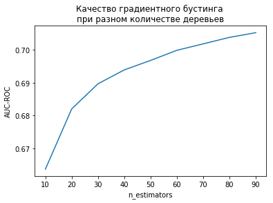

```python
plt.plot(list(map(lambda x: x[0], scores)), list(map(lambda x: x[1], scores)))
plt.title('Качество градиентного бустинга \nпри разном количестве деревьев')
plt.xlabel('n_estimators')
plt.ylabel('AUC-ROC')
plt.show()
```

Сделаем отдельно для 30 деревьев:

```python
%%time
start_time = datetime.datetime.now()

clf = GradientBoostingClassifier(n_estimators=30)
score_30 = cross_val_score(clf, X, y, scoring='roc_auc', cv=kfold).mean()

print('Time elapsed:', datetime.datetime.now() - start_time)
print('score_30 =', score_30)
```

```
Time elapsed: 0:01:43.588264
score_30 = 0.689914373004
Wall time: 1min 43s
```

### Отчет по 1 этапу

1) Пропуски среди своих значений имеют признаки:

```
['first_blood_time',
 'first_blood_team',
 'first_blood_player1',
 'first_blood_player2',
 'radiant_bottle_time',
 'radiant_courier_time',
 'radiant_flying_courier_time',
 'radiant_first_ward_time',
 'dire_bottle_time',
 'dire_courier_time',
 'dire_flying_courier_time',
 'dire_first_ward_time']
```

Это может означать следующее.  
Согласно описанию признаков - "Признаки события "первая кровь" (first blood). Если событие "первая кровь" **не успело произойти** за первые 5 минут, то признаки принимают **пропущенное значение**."  
Поэтому логично, что 4 признака с префиксом `"first_blood_"` имеют пропуски. Это означает, что в этих игровых сессиях за первые 5 минут **не произошло события "первая кровь"**.  
По остальным признакам аналогично - в некоторых игровых сессиях сбытия, описываемые этими признаками, за первые 5 минут **не успели произойти**.

2) Столбец, содержащий целевую переменную, называется **'radiant_win'**.  
3) Кросс-валидация для градиентного бустинга с 30 деревьями длилась 1 мин 43 сек, при этом качество получилось **`AUC-ROC = 0.689914373004`**, **Максимально качество** получилось **`AUC-ROC =0.70528838433438634`** при **90** деревьев.  
4) Для увеличения качества в градиентном бустинге больше 30 деревьев использовать **стоит**. Судя по полученным данным и графику качества, с увеличением числа деревьев больше 30 качество продолжает расти, причем и после 90 деревьев, скорее всего, качество тоже будет расти.  
**Для ускорения обучения** можно уменьшить глубину деревьев и взять часть выборки.

## Подход 2: логистическая регрессия

### 1)

Оценим качество логистической регрессии (sklearn.linear_model.LogisticRegression с L2-регуляризацией) с помощью кросс-валидации по той же схеме, которая использовалась для градиентного бустинга. Подберем при этом лучший параметр регуляризации (C). Какое наилучшее качество у вас получилось? Как оно соотносится с качеством градиентного бустинга? Чем можно объяснить эту разницу? Быстрее ли работает логистическая регрессия по сравнению с градиентным бустингом?

Отмасштабируем признаки:

```python
scaler = StandardScaler()
X_scaled = scaler.fit_transform(X)
```

Оценим качество логистической регрессии для разных **C**:

```python
start_time = datetime.datetime.now()

kfold = KFold(n_splits=5, shuffle=True)
scores = []
for C in range(1, 10):
    clf = LogisticRegression(penalty='l2', C=C)
    score = cross_val_score(clf, X_scaled, y, scoring='roc_auc', cv=kfold).mean()
    scores.append((C, score))

print('Time elapsed:', datetime.datetime.now() - start_time)
```

```
Time elapsed: 0:02:56.927039
```

```python
scores
```

```
[(1, 0.71646720049294133),
 (2, 0.71652759974062374),
 (3, 0.71652825360699779),
 (4, 0.71652161771951461),
 (5, 0.71638860187340436),
 (6, 0.71646311830844511),
 (7, 0.71634806850284583),
 (8, 0.71658654752202167),
 (9, 0.71653168273638035)]
```

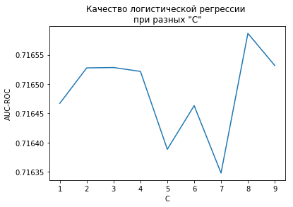

```python
plt.plot(list(map(lambda x: x[0], scores)), list(map(lambda x: x[1], scores)))
plt.title('Качество логистической регрессии \nпри разных "C"')
plt.xlabel('C')
plt.ylabel('AUC-ROC')
plt.show()
```

Максимальное качество **AUC-ROC = 0.71658654752202167** получилось при **C = 8**.

### 2)

Среди признаков в выборке есть категориальные, которые мы использовали как числовые, что вряд ли является хорошей идеей. Категориальных признаков в этой задаче одиннадцать: lobby_type и r1_hero, r2_hero, ..., r5_hero, d1_hero, d2_hero, ..., d5_hero. Уберем их из выборки, и проведем кросс-валидацию для логистической регрессии на новой выборке с подбором лучшего параметра регуляризации. Изменилось ли качество? Чем можно это объяснить?

```python
scaler = StandardScaler()
X_scaled = scaler.fit_transform(X.drop(['lobby_type',
                                        'r1_hero', 'r2_hero', 'r3_hero', 'r4_hero', 'r5_hero',
                                        'd1_hero', 'd2_hero', 'd3_hero', 'd4_hero', 'd5_hero'], axis=1))
```

```python
start_time = datetime.datetime.now()

kfold = KFold(n_splits=5, shuffle=True)
scores = []
for C in range(1, 10):
    clf = LogisticRegression(penalty='l2', C=C)
    score = cross_val_score(clf, X_scaled, y, scoring='roc_auc', cv=kfold).mean()
    scores.append((C, score))

print('Time elapsed:', datetime.datetime.now() - start_time)
```

```
Time elapsed: 0:02:37.736171
```

```python
scores
```

```
[(1, 0.71622375984680831),
 (2, 0.71632359450650429),
 (3, 0.71634225623682402),
 (4, 0.7164372621030578),
 (5, 0.71645658743105634),
 (6, 0.71625532359132782),
 (7, 0.71649329388163063),
 (8, 0.71668914017778218),
 (9, 0.71652764874810304)]
```

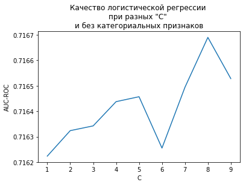

```python
plt.plot(list(map(lambda x: x[0], scores)), list(map(lambda x: x[1], scores)))
plt.title('Качество логистической регрессии \nпри разных "C" \nи без категориальных признаков')
plt.xlabel('C')
plt.ylabel('AUC-ROC')
plt.show()
```

Максимальное качество **AUC-ROC = 0.71668914017778218** получилось при **C = 8**. Оно немного выше, чем до убирания категориальных признаков.

### 3)

На предыдущем шаге мы исключили из выборки признаки rM_hero и dM_hero, которые показывают, какие именно герои играли за каждую команду. Это важные признаки — герои имеют разные характеристики, и некоторые из них выигрывают чаще, чем другие. Выясним из данных, сколько различных идентификаторов героев существует в данной игре (может пригодиться фукнция unique или value_counts).

Посмотрим, сколько различных идентификаторов героев существует:

```python
[len(X[hero].unique()) for hero in ['r1_hero', 'r2_hero', 'r3_hero', 'r4_hero', 'r5_hero',
                                        'd1_hero', 'd2_hero', 'd3_hero', 'd4_hero', 'd5_hero']]
```

```
[108, 108, 108, 108, 108, 108, 108, 108, 108, 108]
```

Терерь посмотрим, в каком диапазоне располагаются значения идентификаторов героев:

```python
[(X[hero].min(), X[hero].max())  for hero in ['r1_hero', 'r2_hero', 'r3_hero', 'r4_hero', 'r5_hero',
                                        'd1_hero', 'd2_hero', 'd3_hero', 'd4_hero', 'd5_hero']]
```

```
[(1, 112),
 (1, 112),
 (1, 112),
 (1, 112),
 (1, 112),
 (1, 112),
 (1, 112),
 (1, 112),
 (1, 112),
 (1, 112)]
```

**ВЫВОД по этому пункту**:  
Получилось, что **количество** различных идентификаторов героев составляет **108**. Тем не менее, **значения** идентификаторов героев (по каким-то причинам, пока не понятным) лежат **в диапазоне от 1 до 112** (видимо, какие-то номера отсутствуют). Поэтому, чтобы в следующем пункте код работал корректно, нужно брать **N = 112**.

### 4)

Воспользуемся подходом "мешок слов" для кодирования информации о героях. Пусть всего в игре имеет N различных героев. Сформируем N признаков, при этом i-й будет равен нулю, если i-й герой не участвовал в матче; единице, если i-й герой играл за команду Radiant; минус единице, если i-й герой играл за команду Dire. Ниже можно найти код, который выполняет данное преобразование. Добавим полученные признаки к числовым, которые вы использовали во втором пункте данного этапа.

```python
# Код для формирования "мешка слов" по героям
# N — количество различных героев в выборке

N = 112 # см. вывод к предыдущему пункту
X_pick = np.zeros((X.shape[0], N))

for i, match_id in enumerate(X.index):
    for p in range(5):
        X_pick[i, X.ix[match_id, 'r%d_hero' % (p+1)]-1] = 1
        X_pick[i, X.ix[match_id, 'd%d_hero' % (p+1)]-1] = -1
```

Добавим полученные признаки к числовым:

```python
X_scaled_hero = np.hstack((X_scaled, X_pick))
```

### 5)

Проведем кросс-валидацию для логистической регрессии на новой выборке с подбором лучшего параметра регуляризации. Какое получилось качество? Улучшилось ли оно? Чем можно это объяснить?

```python
start_time = datetime.datetime.now()

kfold = KFold(n_splits=5, shuffle=True)
scores = []
for C in range(1, 10):
    clf = LogisticRegression(penalty='l2', C=C)
    score = cross_val_score(clf, X_scaled_hero, y, scoring='roc_auc', cv=kfold, n_jobs=3).mean()
    scores.append((C, score))

print('Time elapsed:', datetime.datetime.now() - start_time)
```

```
Time elapsed: 0:06:12.949739
```

```python
start_time = datetime.datetime.now()

kfold = KFold(n_splits=5, shuffle=True)
scores = []
for C in range(1, 10):
    clf = LogisticRegression(penalty='l2', C=C)
    score = cross_val_score(clf, X_scaled_hero, y, scoring='roc_auc', cv=kfold).mean()
    scores.append((C, score))

print('Time elapsed:', datetime.datetime.now() - start_time)
```

```
Time elapsed: 0:05:40.842137
```

```python
scores
```

```
[(1, 0.75190789923069246),
 (2, 0.7520303841382675),
 (3, 0.75172432536101541),
 (4, 0.75183109092096112),
 (5, 0.75167233427233549),
 (6, 0.75211223486086798),
 (7, 0.7520731018516148),
 (8, 0.75179161091266833),
 (9, 0.75188622404777072)]
```

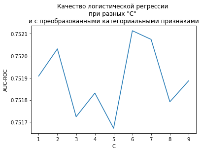

```python
plt.plot(list(map(lambda x: x[0], scores)), list(map(lambda x: x[1], scores)))
plt.title('Качество логистической регрессии \nпри разных "C" \nи с преобразованными категориальными признаками')
plt.xlabel('C')
plt.ylabel('AUC-ROC')
plt.show()
```

Максимальное качество **AUC-ROC = 0.75211223486086798** получилось при **C = 6**. Это **значительно выше**, чем без категориальных признаков.

### 6)

Построим предсказания вероятностей победы команды Radiant для тестовой выборки с помощью лучшей из изученных моделей (лучшей с точки зрения AUC-ROC на кросс-валидации). Убедимся, что предсказанные вероятности адекватные — находятся на отрезке [0, 1], не совпадают между собой (т.е. что модель не получилась константной).

##### Загрузим и предобработаем тестовые данные

Учтем, что **scaler** у нас уже обучен.

```python
X_test = pd.read_csv('data/features_test.csv', index_col='match_id')
X_test.head()
```

| match_id | start_time | lobby_type | r1_hero | r1_level | r1_xp | r1_gold | r1_lh | r1_kills | r1_deaths | r1_items | ... | radiant_ward_sentry_count | radiant_first_ward_time | dire_bottle_time | dire_courier_time | dire_flying_courier_time | dire_tpscroll_count | dire_boots_count | dire_ward_observer_count | dire_ward_sentry_count | dire_first_ward_time |
| --- | --- | --- | --- | --- | --- | --- | --- | --- | --- | --- | --- | --- | --- | --- | --- | --- | --- | --- | --- | --- | --- |
| 6 | 1430287923 | 0 | 93 | 4 | 1103 | 1089 | 8 | 0 | 1 | 9 | ... | 0 | 12.0 | 247.0 | -86.0 | 272.0 | 3 | 4 | 2 | 0 | 118.0 |
| 7 | 1430293357 | 1 | 20 | 2 | 556 | 570 | 1 | 0 | 0 | 9 | ... | 2 | -29.0 | 168.0 | -54.0 | NaN | 3 | 2 | 2 | 1 | 16.0 |
| 10 | 1430301774 | 1 | 112 | 2 | 751 | 808 | 1 | 0 | 0 | 13 | ... | 1 | -22.0 | 46.0 | -87.0 | 186.0 | 1 | 3 | 3 | 0 | -34.0 |
| 13 | 1430323933 | 1 | 27 | 3 | 708 | 903 | 1 | 1 | 1 | 11 | ... | 2 | -49.0 | 30.0 | -89.0 | 210.0 | 3 | 4 | 2 | 1 | -26.0 |
| 16 | 1430331112 | 1 | 39 | 4 | 1259 | 661 | 4 | 0 | 0 | 9 | ... | 0 | 36.0 | 180.0 | -86.0 | 180.0 | 1 | 3 | 2 | 1 | -33.0 |

5 rows × 102 columns

```python
X_test.info()
```

```
<class 'pandas.core.frame.DataFrame'>
Int64Index: 17177 entries, 6 to 114398
Columns: 102 entries, start_time to dire_first_ward_time
dtypes: float64(12), int64(90)
memory usage: 13.5 MB
```

```python
X_test.count()
```

```
start_time                     17177
lobby_type                     17177
r1_hero                        17177
r1_level                       17177
r1_xp                          17177
r1_gold                        17177
r1_lh                          17177
r1_kills                       17177
r1_deaths                      17177
r1_items                       17177
r2_hero                        17177
r2_level                       17177
r2_xp                          17177
r2_gold                        17177
r2_lh                          17177
r2_kills                       17177
r2_deaths                      17177
r2_items                       17177
r3_hero                        17177
r3_level                       17177
r3_xp                          17177
r3_gold                        17177
r3_lh                          17177
r3_kills                       17177
r3_deaths                      17177
r3_items                       17177
r4_hero                        17177
r4_level                       17177
r4_xp                          17177
r4_gold                        17177
                               ...
d4_deaths                      17177
d4_items                       17177
d5_hero                        17177
d5_level                       17177
d5_xp                          17177
d5_gold                        17177
d5_lh                          17177
d5_kills                       17177
d5_deaths                      17177
d5_items                       17177
first_blood_time               13625
first_blood_team               13625
first_blood_player1            13625
first_blood_player2             9411
radiant_bottle_time            14282
radiant_courier_time           17050
radiant_flying_courier_time    12292
radiant_tpscroll_count         17177
radiant_boots_count            17177
radiant_ward_observer_count    17177
radiant_ward_sentry_count      17177
radiant_first_ward_time        16847
dire_bottle_time               14335
dire_courier_time              17047
dire_flying_courier_time       12653
dire_tpscroll_count            17177
dire_boots_count               17177
dire_ward_observer_count       17177
dire_ward_sentry_count         17177
dire_first_ward_time           16914
Length: 102, dtype: int64
```

Видим наличие пропусков. Заполним их также нулями.

```python
X_test.fillna(0, inplace=True)
```

```python
X_test_scaled = scaler.transform(X_test.drop(['lobby_type',
                                        'r1_hero', 'r2_hero', 'r3_hero', 'r4_hero', 'r5_hero',
                                        'd1_hero', 'd2_hero', 'd3_hero', 'd4_hero', 'd5_hero'], axis=1))
```

```python
N = 112 # см. вывод к предыдущему пункту
X_pick = np.zeros((X_test.shape[0], N))

for i, match_id in enumerate(X_test.index):
    for p in range(5):
        X_pick[i, X_test.ix[match_id, 'r%d_hero' % (p+1)]-1] = 1
        X_pick[i, X_test.ix[match_id, 'd%d_hero' % (p+1)]-1] = -1
```

```python
X_test_scaled_hero = np.hstack((X_test_scaled, X_pick))
```

Обучим классификатор на подобранных параметрах и сделааем предсказание **1 класса** для тестовой выборки:

```python
C = 6
clf = LogisticRegression(penalty='l2', C=C)
clf.fit(X_scaled_hero, y)
pred = clf.predict_proba(X_test_scaled_hero)[:, 1]
```

```python
pred
```

```
array([ 0.82506027,  0.75453393,  0.18724452, ...,  0.23523887,
        0.62911525,  0.42441391])
```

Убедимся, что предсказания адекватны (то есть лежат в диапзоне [0, 1] и не константа):

```python
pred.min(), pred.max()
```

```
(0.0084611801640181138, 0.99643715510874242)
```

### Отчет по 2 этапу

1. Максимальное качество у логистической регрессии **над всеми** исходными признаками получилось **AUC-ROC = 0.71658654752202167** при **C = 8**.  
   Это немного выше, чем для градиентного бустинга. Это можно объяснить, например, тем, что достаточно много числовых признаков, которые хорошо обрабатываются линейными алгоритмами. Да и сама природа решаемой задачи предполагает линейные зависимости (на уровне понятия - характеристики игры зависят, несомненно, от опыта, и скорее всего - как раз линейно).  
   Логистическая регрессия работает быстрее градиентного бустинга примерно на порядок.
2. Максимальное качество логистической регрессии **при удалении категориальных** признаков получилось **AUC-ROC = 0.71668914017778218** при **C = 8**. Оно немного выше, чем до убирания категориальных признаков.  
   Это можно объяснить тем, что категориальные признаки воспринимались как числовые, не являясь таковыми. В результате они были **подобны шуму**, который только ухудшал качество классификации.
3. Различных идентификаторов героев по **количеству** составило **108**. Тем не менее, **значения** идентификаторов героев (по каким-то причинам, пока не понятным) лежат **в диапазоне от 1 до 112** (видимо, какие-то номера отсутствуют). Поэтому, чтобы в следующем пункте код работал корректно, нужно брать **N = 112**.
4. При добавлении **"мешка слов"** по героям **максимальное качество** составило **AUC-ROC = 0.75211223486086798** при **C = 6**. Это **значительно выше**, чем без категориальных признаков. Это и логично, поскольку добавились правильным образом используемые дополнительные признаки (категориальные).
5. **Минимальное** и **максимальное** значение прогноза на тестовой выборке получилось у лучшего из алгоритмов такие:  
   **(0.0084611801640181138, 0.99643715510874242)**

## Проверка финальной модели

Сформируем решение для отправки на **Kaggle**, и отправим.

```python
pd.DataFrame(pred, index=X_test.index, columns=['radiant_win']).to_csv('data/submission.csv')
```

На **Kaggle** получилось **AUC-ROC = 0.75527**:

[figure not shown]